# North Atlanic Alnbacore

Operating Model

Laurence Kell

26/03/2015

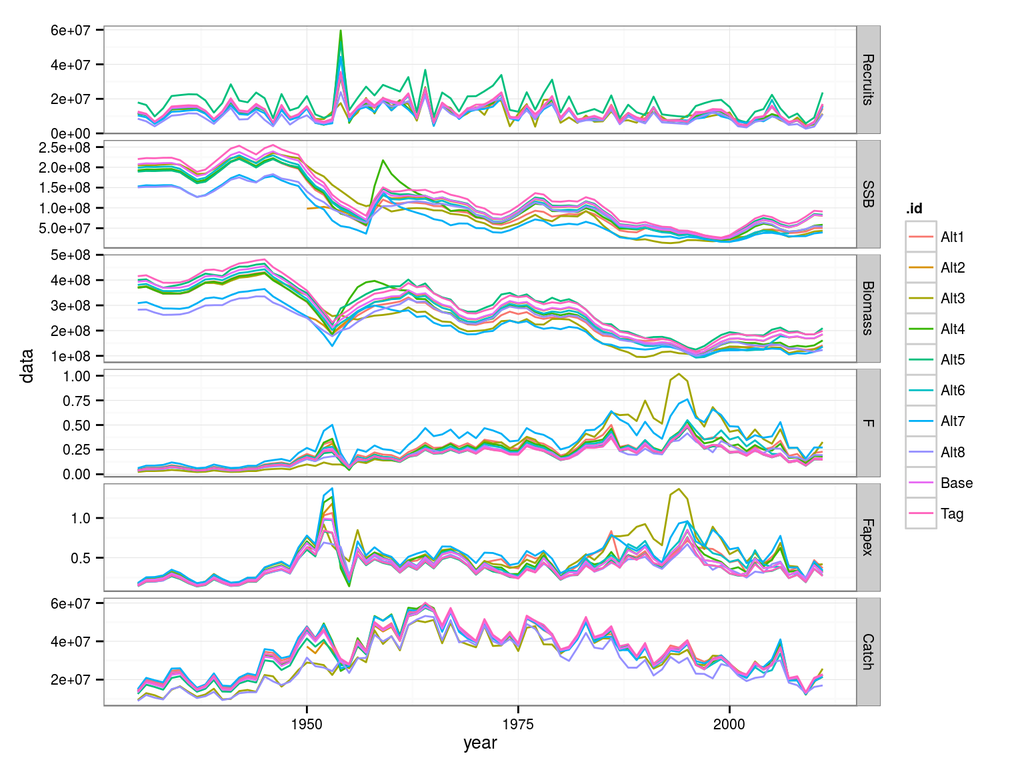

**Figure 1** Time series of recruits, SSB, biomass, mean F, F apex and Catch

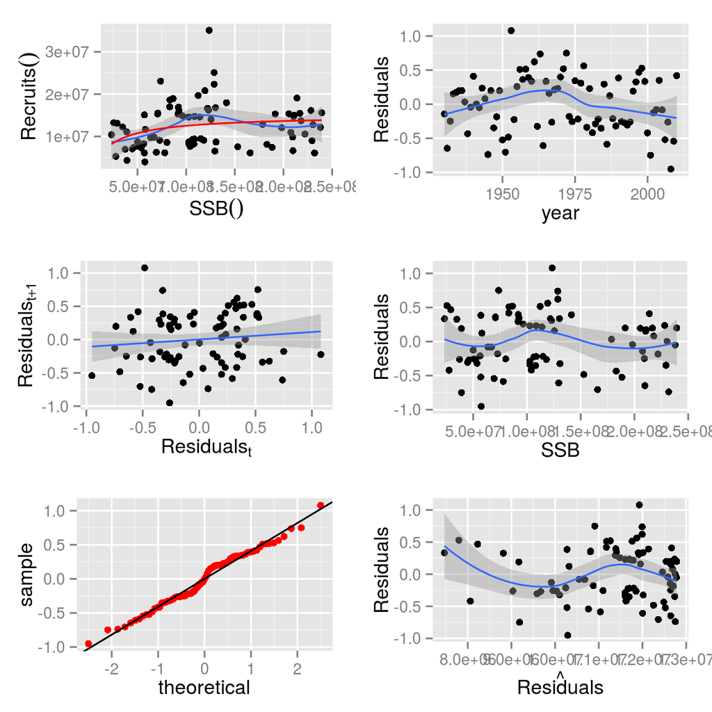

**Figure 2** Stock recruitment fit with diagnostics for base case.

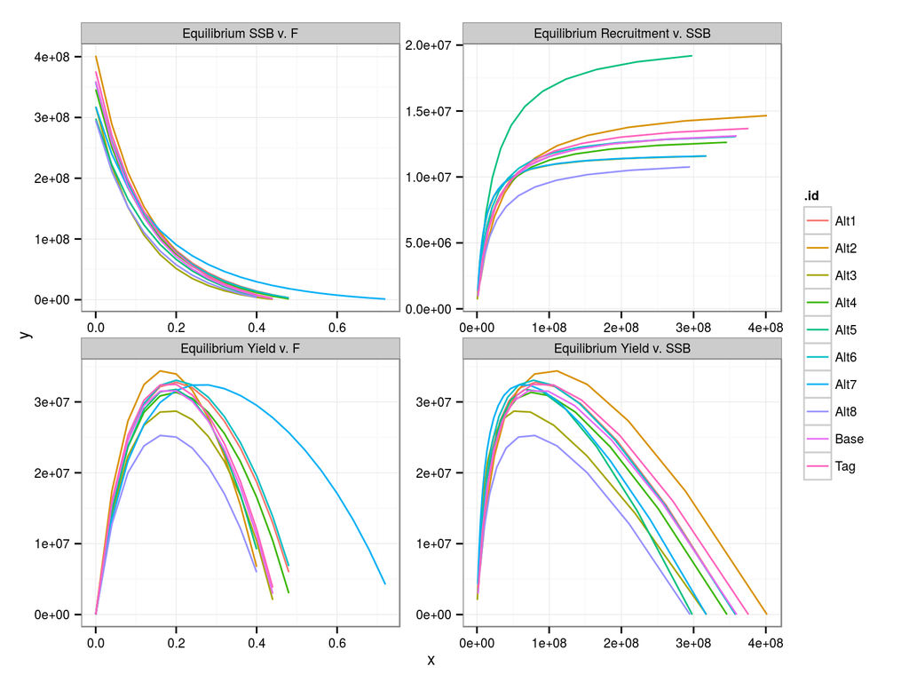

**Figure 3** Equilibrium curves

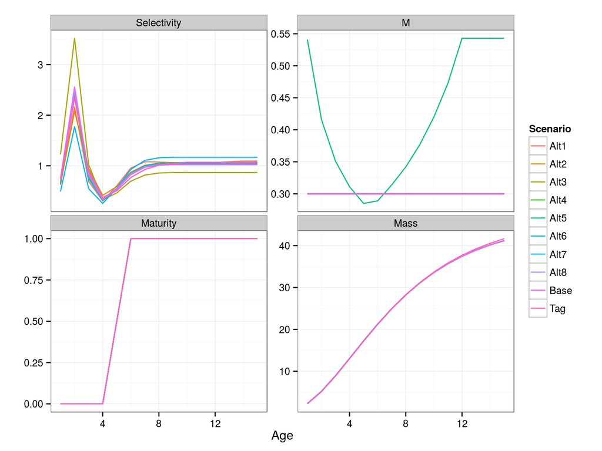

**Figure 4** Future parameter vectors

# Comparison with biomass dynamic model

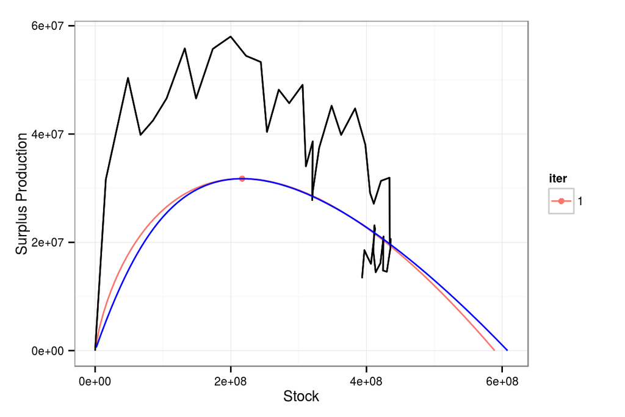

**Figure 5** Comparison of age based and Pella Tomlonson production functions.

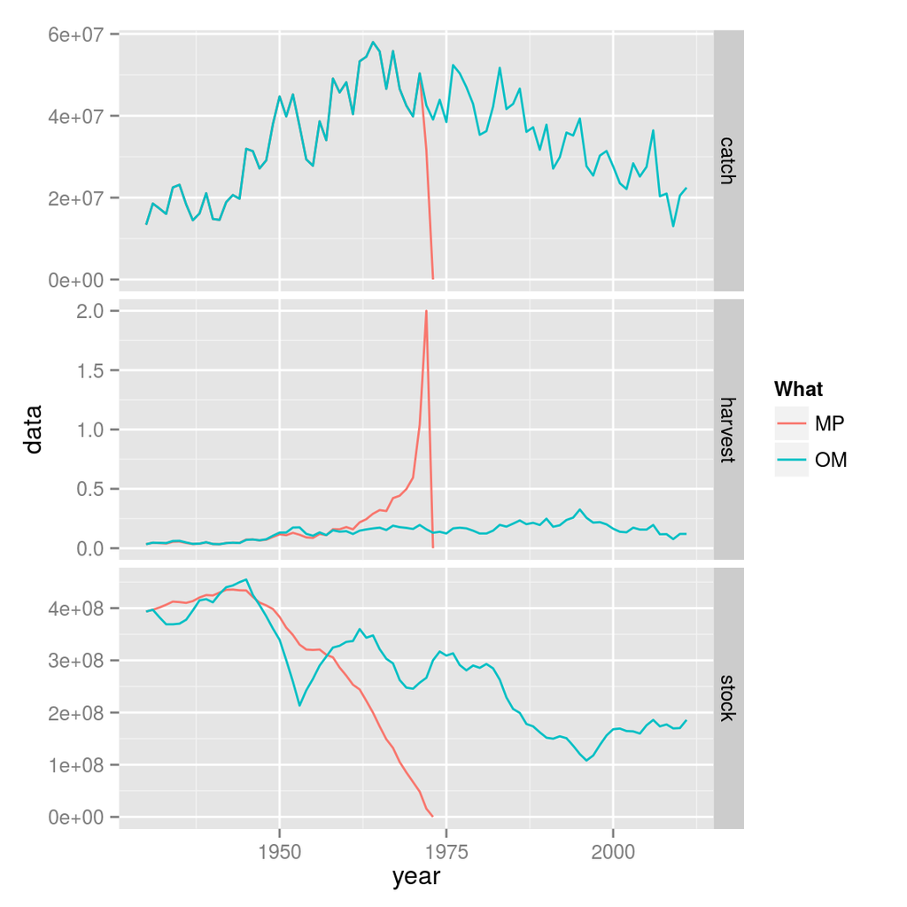

**Figure 6** Simulation with biomass production function

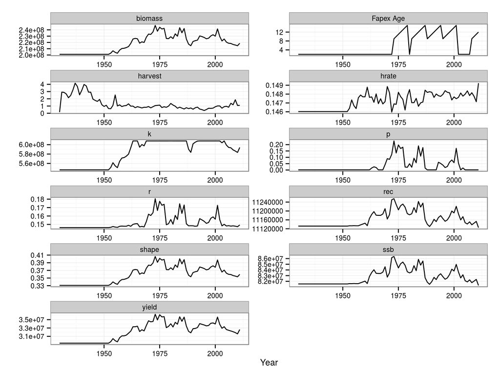

**Figure 7** Time series of population parameters

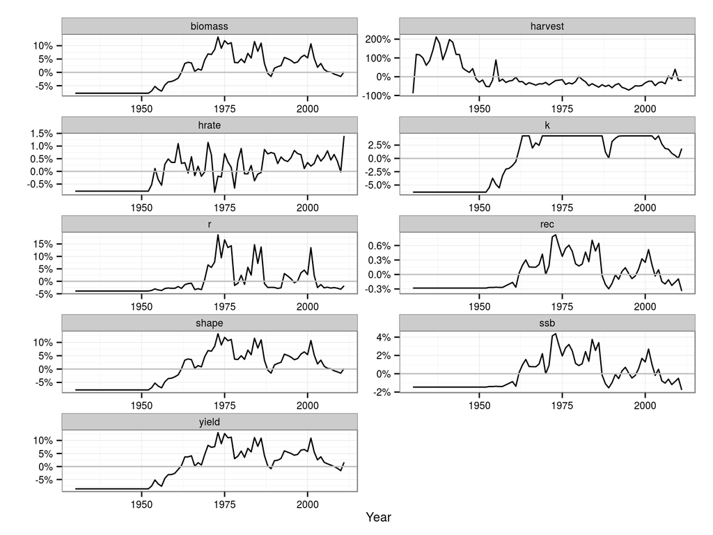

**Figure 8** Relative time series of population parameters

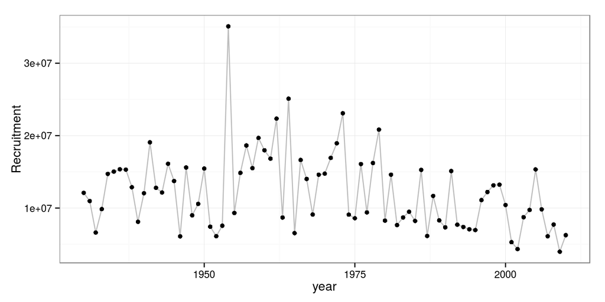

**Figure 9** Recruitment in base case

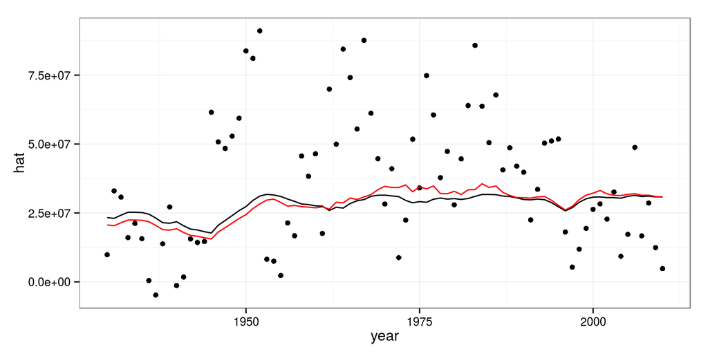

**Figure 10** Surplus production, lines are expected values (red is the non-stationary function) and points are the observered values. CV is 94 %

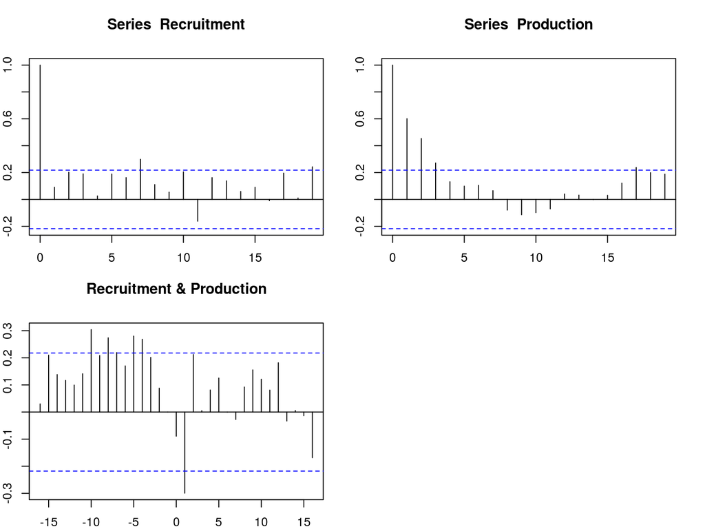

**Figure 11** Auto and cross correlation for recruitment and production, showing production is driven by recruitment 5 to 10 years earlierand that although recruitment exhibits white noise there is autocorrelation in productivity.

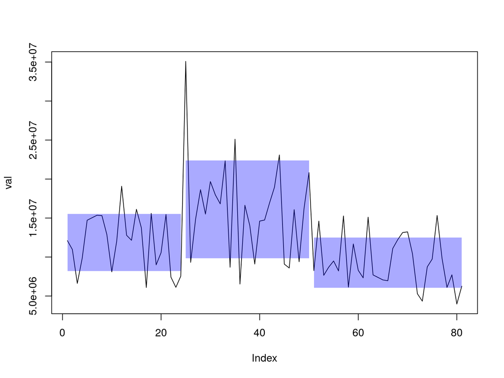

```
[1] 24 50 81
```

**Figure 12** Shifts in recruitment

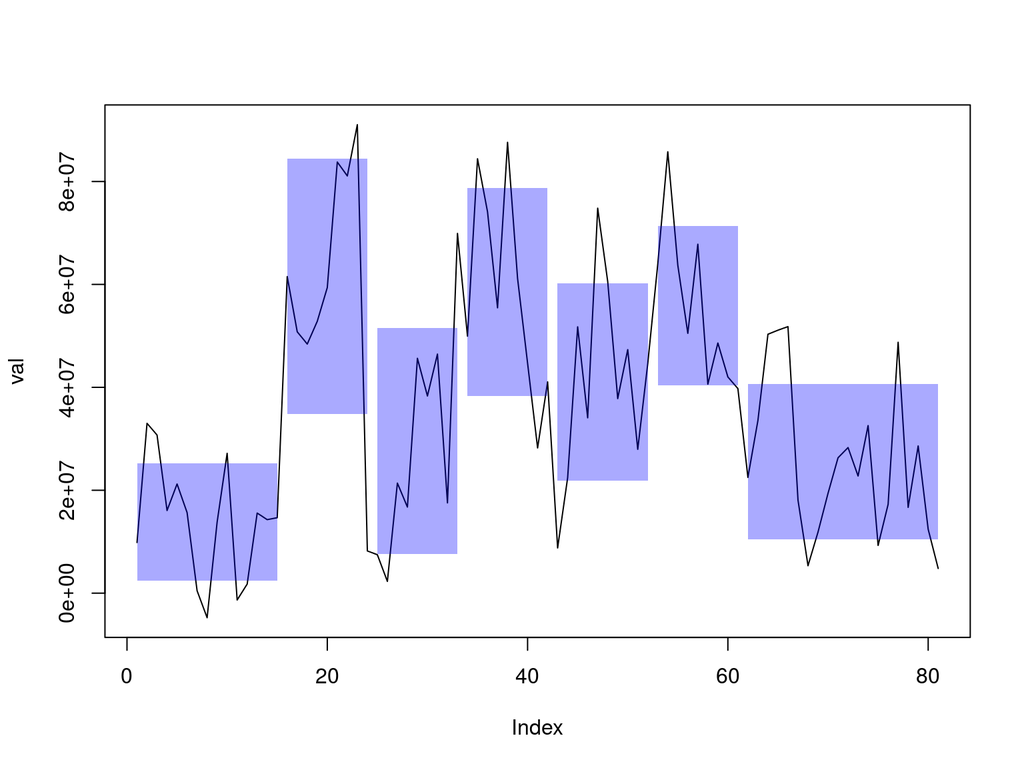

```
[1] 15 24 33 42 52 61 81
```

**Figure 13** Shifts in production

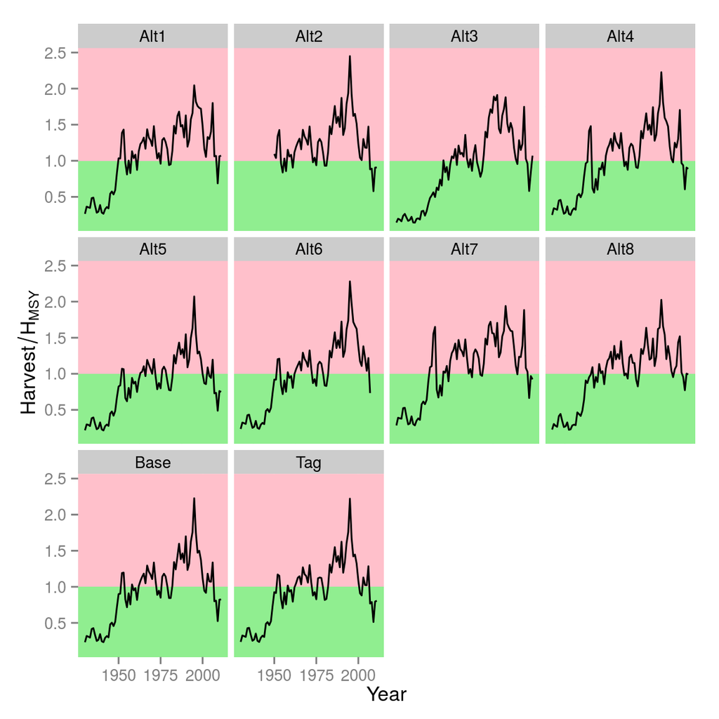

**Figure 14** Harvest rate relative to MSY benchmark by scenario.

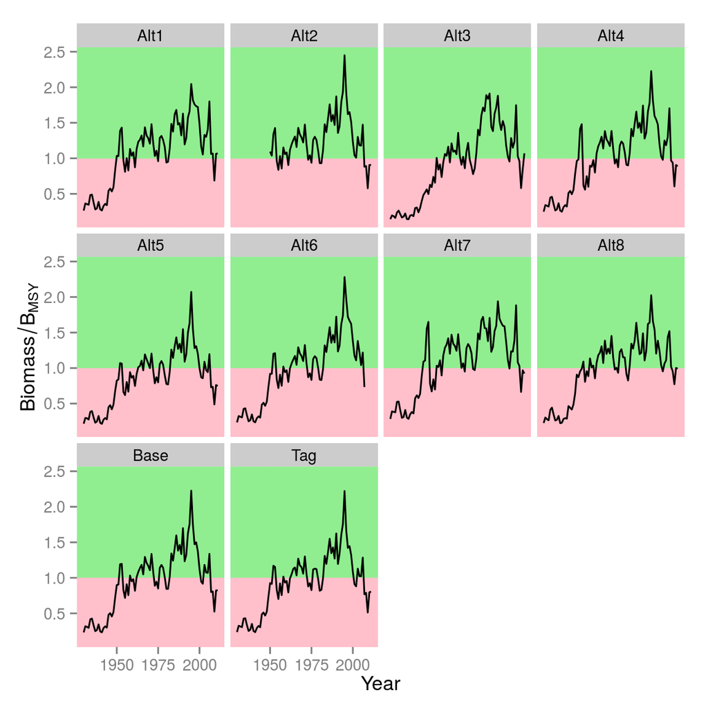

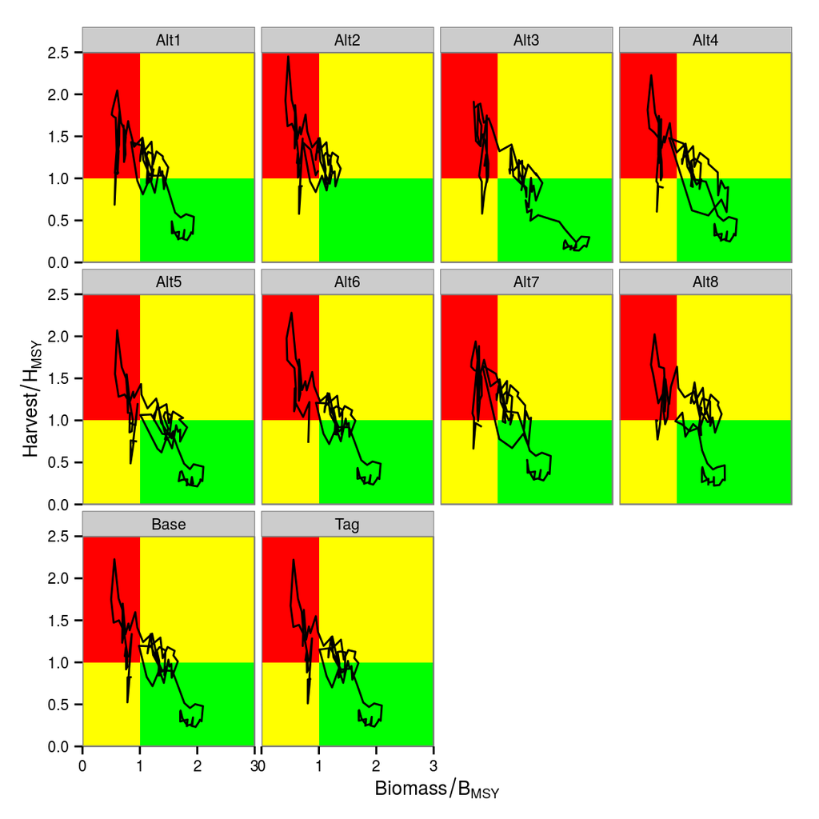

**Figure 16** Kobe Phase Plots by scenario .